# 02 Intervalos de Confianza MAS

FES Acatlán

febrero de 2022

## Intervalos de confianza Muestreo Aleatorio Simple

Un intervalo de confianza se expresa de la siguiente manera:

Si extraemos muestra de una población, una y otra vez, y construimos un intervalo de confianza para cada muestra obtenida, esperamos que el 95% de os intervalos resultantes incluyan a nuestro parámetro $\theta$.

Notar que en la realidad, no realizaremos k muestras, sino sólo realizaremos 1 muestra y no conoceremos el valor del parámetro poblacional $\theta$.

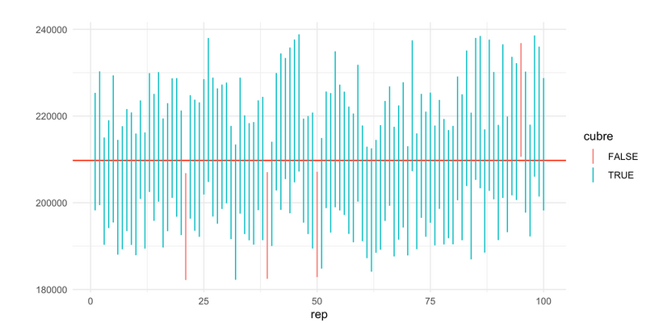

cobertura

**Ejercicio**. Piensen la forma de crear una gráfica similar a la anterior.

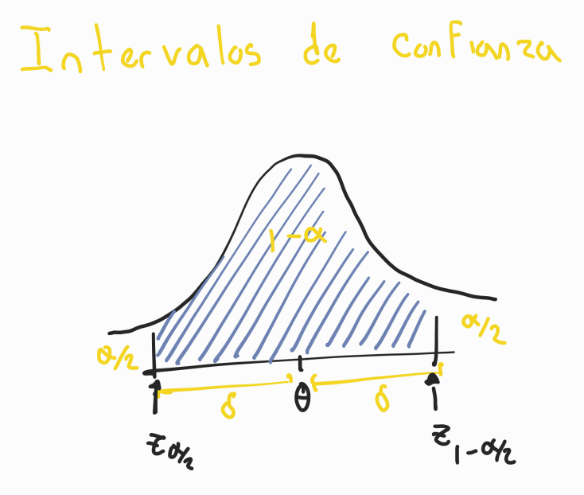

int conf

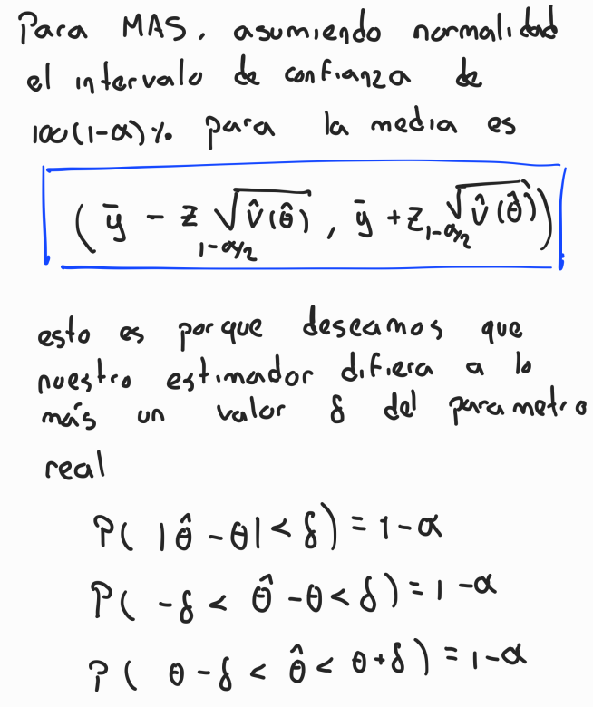

int conf

A $\delta$ le llamaremos precisión y a $1-\alpha$ le llamaremos confianza.

Antes, eran muy utilizadas las tablas con los valores de los cuantiles de una normal

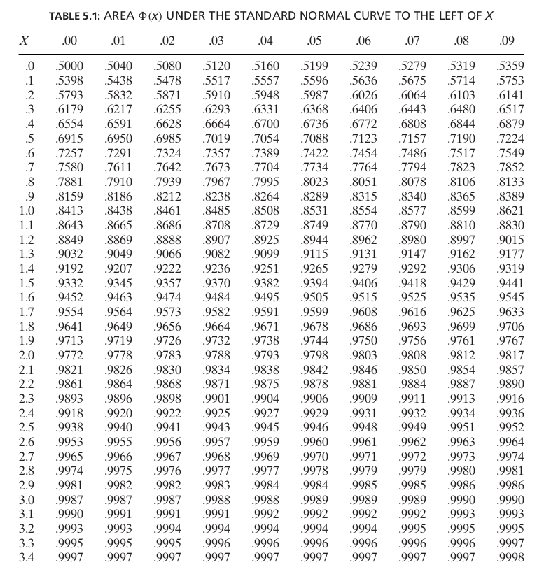

int conf

¿En R como podemos obtener los valores de los cualtiles, asumiendo normalidad?

```r
# pnorm, nos da la probabilidad acumulada hasta cierto cuantil
pnorm(q = 0,mean = 0, sd = 1)
```

```
## [1] 0.5
```

```r
# qnorm nos da el cualtil que equivale a la probabilidad acumulada
qnorm(p = 0.5, mean = 0, sd = 1)
```

```
## [1] 0
```

Así, para saber el cuantil que necesitamos para un intervalo de confianza del 95% para una normal con media cero y desviación estándar 1, necesitamos el cuantil 0.975 para que en cada cola haya 0.025

```r
qnorm(p = 0.975, mean = 0, sd = 1)
```

```
## [1] 1.959964
```

```r
#utilizando la notación de arriba
alpha = 0.05
valor = 1 - (alpha/2)
print(valor)
```

```
## [1] 0.975
```

```r
z <- qnorm(p = 0.975, mean = 0, sd = 1)
print(z)
```

```
## [1] 1.959964
```

Notar que en una distribución normal, el valor de $\alpha/2$ es el mismo valor vaor que de $1 - \alpha/2$ sólo que con signo contrario

```r
qnorm(0.025)
```

```
## [1] -1.959964
```

```r
qnorm(0.975)
```

```
## [1] 1.959964
```

La ventaja de utilizar un software estadístico es que no estamos limitados a una distribución normal estánar, puede ser cualquier distribción con una amplia gama de parámetros.

Definir la precisión y confianza que deseamos en un estimador, nos da un primer paso para todos los elementos que debemos considerar para obtener una muestra.

Entre 2 intervalos de confianza con el mismo nivel de confianza, preferiremos el que sea más angosto.

**Ejercicio**. De los datos de precios de casas, obtener una muestra aleatoria simple de tamaño 150 y construir un intervalo de confianza.